# Assingment07: Machine Learning

Author

Yuyan He and Fartun Adan

# Exercise 01:

## 1. Estimate a Model

```r
library(tidyverse)
library(tidymodels)

data <- read.csv("data/restaurant_grades.csv")


## split data
set.seed(20201020)
data_split <- initial_split(data = data, prop = 0.8)
data_train <- training(x = data_split)
data_test <- testing(x = data_split)

## create a recipe
cart_rec <-
  recipe(grade ~ ., data = data_train) %>%
  themis::step_downsample(grade)

## create a cart model object
cart_mod <-
  decision_tree() %>%
  set_engine(engine = "rpart") %>%
  set_mode(mode = "classification")

## workflow
cart_wf <- workflow() %>%
  add_recipe(cart_rec) %>%
  add_model(cart_mod)

## fit the model
cart_fit <- cart_wf %>%
  fit(data = data_train)

## predict the predicted class and the predicted probability of each class
predictions <- bind_cols(
  data_test,
  predict(object = cart_fit, new_data = data_test),
  predict(object = cart_fit, new_data = data_test, type = "prob")
)
```

## 2. Evaluate the Model

```r
## confusion matrix
predictions |>
  mutate(grade = factor(grade)) |>
  conf_mat(truth = grade,
           estimate = .pred_class)
```

```
          Truth
Prediction    A Not A
     A     6114    65
     Not A 2144  1313
```

```r
## calculating precision and recall
predictions |>
  mutate(grade = factor(grade)) |>
  precision(truth = grade,
            estimate = .pred_class)
```

```
# A tibble: 1 × 3
  .metric   .estimator .estimate
  <chr>     <chr>          <dbl>
1 precision binary         0.989
```

```r
predictions |>
  mutate(grade = factor(grade)) |>
  recall(truth = grade,
         estimate = .pred_class)
```

```
# A tibble: 1 × 3
  .metric .estimator .estimate
  <chr>   <chr>          <dbl>
1 recall  binary         0.740
```

**Quality of the model:** The model has very high precision of 98.9%, and a moderate recall of 74.0%, missing many actual positives.

## 3. Improvement

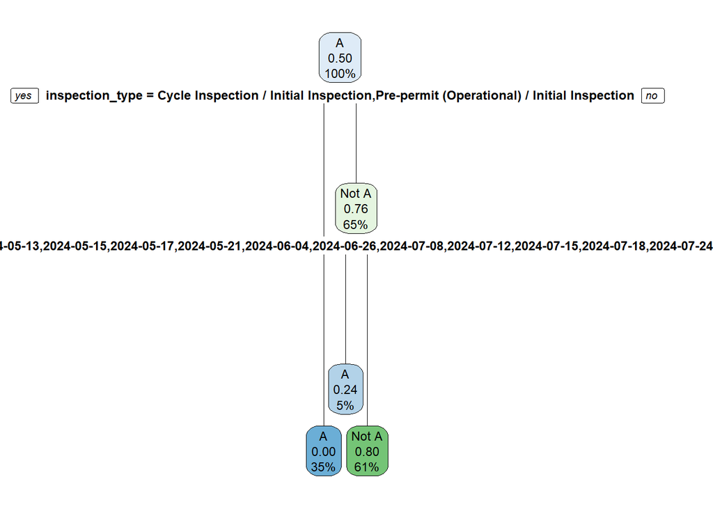

```r
## create a tree
rpart.plot::rpart.plot(x = cart_fit$fit$fit$fit)
```

We can see from the tree that the parting rule for predicting in this model are inspection type and date. The inspection type might make sense, but the date sounds a bit far fetched when it comes to grading. For better prediction, it might be wise to remove date as a predictor for the model. Besides, since we have so many variables in the dataset, maybe linear regression is better model for such prediction as it could give a more comprehensive consideration of all the variables.

## 4. Variable importance

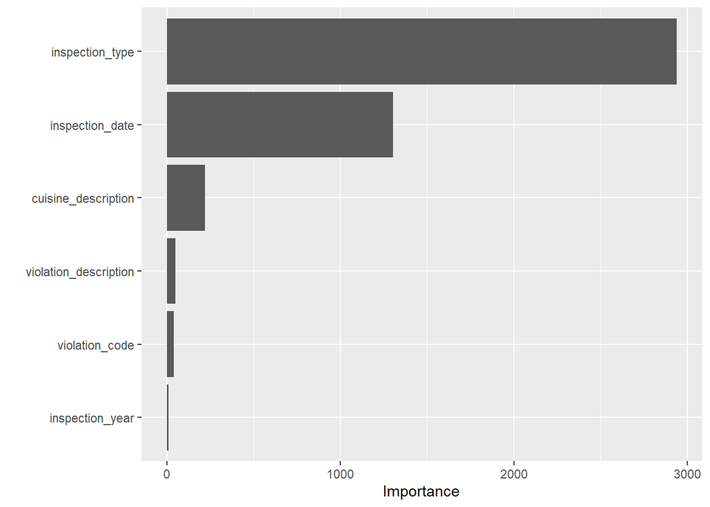

```r
library(vip)
cart_fit |>
  extract_fit_parsnip() |>
  vip(num_features = 10)
```

Comment: A higher feature importance score indicates that the feature plays a more crucial role in the decision-making process of the tree, leading to better separation of classes or more accurate predictions. In our case, inspection type and inspection date have higher weights in the parting process, i.e. these 2 variables mostly determined which grade to assign in our model.

## 5. Application

By interpreting confusion matrix and check variable importance, the ombudsman could use this model to check if there is any systematic grading bias, which is related to certain inspection type, date etc. They could better allocate manpower and make sure the grading is credible.

# Exercise 02:

**Set up the data:**

```r
Chicago_modeling <- Chicago |>
slice(1:5678)

Chicago_implementation <- Chicago |>
slice(5679:5698) |>
select(-ridership)
```

## 1. Convert date into a usable variable

```r
library(lubridate)

Chicago_modeling <- Chicago_modeling |>
  mutate(weekday = wday(date, label = TRUE, locale = "English")) |>
  mutate(month = month(date, label = TRUE, locale = "English")) |>
  mutate(yearday = yday(date))
```

## 2. Set up a testing environment

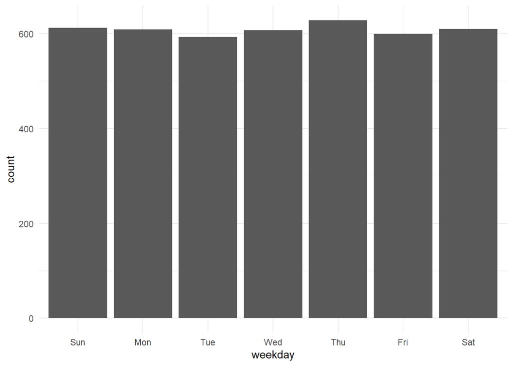

```r
set.seed(20211101)

## Split data
chicago_split <- initial_split(data = Chicago_modeling, prop = 0.75)
chicago_train <- training(x = chicago_split)
chicago_test <- testing(x = chicago_split)

## Exploratory Data Analysis
chicago_train |>
  ggplot(aes(x = weekday)) +
  geom_bar() +
  theme_minimal()
```

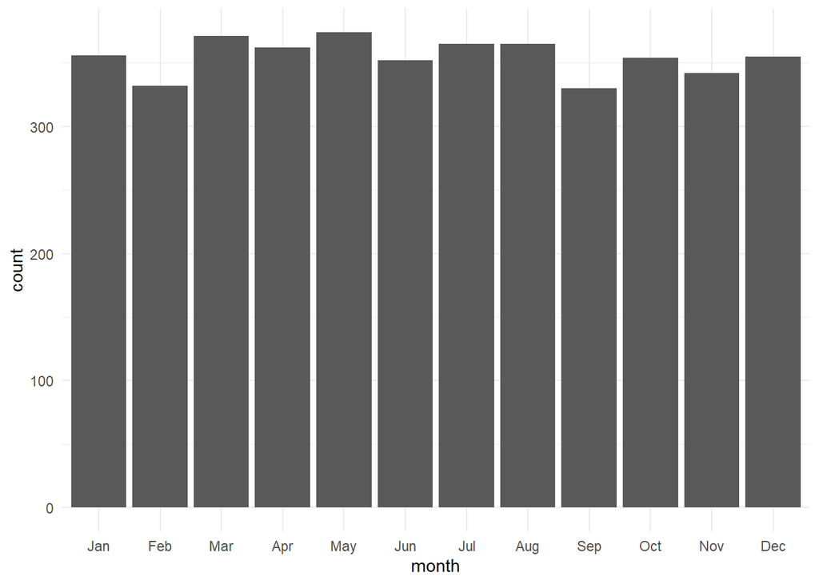

```r
chicago_train |>
  ggplot(aes(x = month)) +
  geom_bar() +
  theme_minimal()
```

```r
## v-fold
folds <- vfold_cv(data = chicago_train, v = 10, repeats = 1)
```

## 3. Test different approaches

Create a recipe:

```r
chicago_rec <-
  recipe(ridership ~ ., data = chicago_train) %>%
  step_holiday(date) |>
  step_rm(date) |>
  step_dummy(all_nominal_predictors())
```

### Model 1: Lasso:

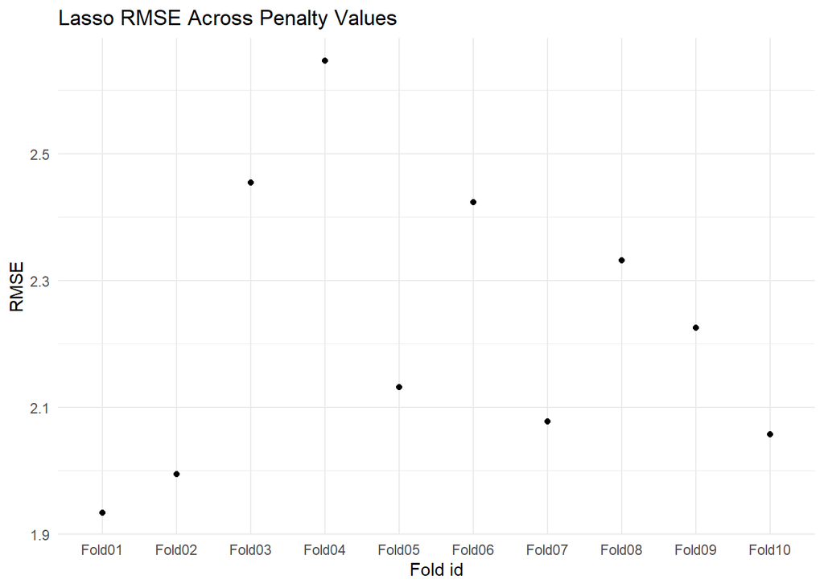

```r
## create a tuning grid for lasso regularization, varying the regularization penalty
lasso_grid <- grid_regular(penalty(), levels = 10)

## Lasso specification
lasso_mod <- linear_reg(
  penalty = tune(),
  mixture = 1
) %>%
  set_engine("glmnet")

## Lasso workflow
lasso_wf <- workflow() %>%
  add_recipe(chicago_rec) %>%
  add_model(lasso_mod)

## fit
lasso_cv <- lasso_wf %>%
  tune_grid(
    resamples = folds,
    grid = lasso_grid
  )

## Calculate RMSE
lasso_rmse <- lasso_cv %>%
  collect_metrics(summarize = FALSE) %>%
  filter(.metric == "rmse")

## Plot RMSE
lasso_rmse |>
  group_by(id) |>
  summarize(RMSE = mean(.estimate)) |>
  ggplot(aes(x = id, y = RMSE)) +
  geom_point() +
  labs(
    x = "Fold id",
    y = "RMSE",
    title = "Lasso RMSE Across Penalty Values"
  ) +
  theme_minimal()
```

```r
## Mean RMSE across 10 folds
mean(lasso_rmse$.estimate)
```

```
[1] 2.227615
```

### Model 2: Random Forest:

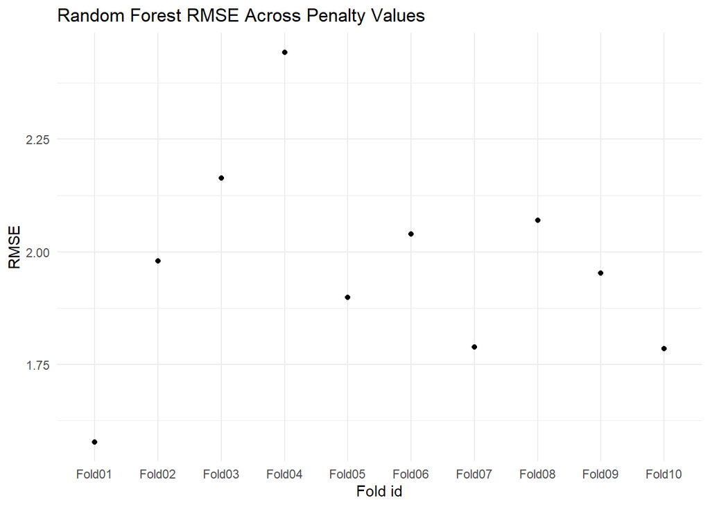

```r
rf_mod <- rand_forest() |>
  set_mode(mode = "regression") |>
  set_engine(
    engine = "ranger",
    importance = "impurity",
    num.threads = 4
  )

## Random forest workflow
rf_wf <- workflow() |>
  add_recipe(chicago_rec) |>
  add_model(rf_mod)

## fit
rf_resamples <- rf_wf |>
  fit_resamples(resamples = folds)

## Calculate RMSE
rf_rmse <- rf_resamples %>%
  collect_metrics(summarize = FALSE) %>%
  filter(.metric == "rmse")

## Plot RMSE
rf_rmse |>
  ggplot(aes(x = id, y = .estimate)) +
  geom_point() +
  labs(
    x = "Fold id",
    y = "RMSE",
    title = "Random Forest RMSE Across Penalty Values"
  ) +
  theme_minimal()
```

```r
## Mean RMSE across 10 folds
mean(rf_rmse$.estimate)
```

```
[1] 1.969775
```

### Model 3: Decision Tree:

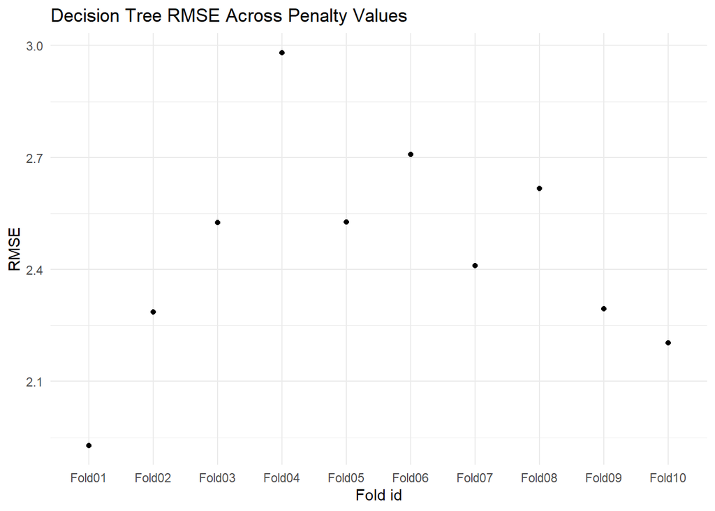

```r
dt_mod <-
  decision_tree() %>%
  set_engine(engine = "rpart") %>%
  set_mode(mode = "regression")

## Decision tree workflow
dt_wf <- workflow() %>%
  add_recipe(chicago_rec) %>%
  add_model(dt_mod)

## fit
dt_resamples <- dt_wf %>%
  fit_resamples(resamples = folds)

## Calculate RMSE
dt_rmse <- dt_resamples %>%
  collect_metrics(summarize = FALSE) %>%
  filter(.metric == "rmse")

## Plot RMSE
dt_rmse |>
  ggplot(aes(x = id, y = .estimate)) +
  geom_point() +
  labs(
    x = "Fold id",
    y = "RMSE",
    title = "Decision Tree RMSE Across Penalty Values"
  ) +
  theme_minimal()
```

```r
## Mean RMSE across 10 folds
mean(dt_rmse$.estimate)
```

```
[1] 2.448278
```

## 4. Estimate the out-of-sample error rate

```r
## get the best model from random forest as it has the lowest RMSE
rf_best <- rf_resamples %>%
  select_best(metric = "rmse")

## generate final workflow, fit, and predict on test data
final_wf <- finalize_workflow(rf_wf, rf_best)
final_fit <- final_wf %>% fit(data = chicago_train)
test_pred <- predict(final_fit, chicago_test)

## getting rmse
test_pred <- chicago_test %>%
  select(ridership) %>%
  bind_cols(test_pred)

rmse(test_pred, truth = ridership, estimate = .pred)
```

```
# A tibble: 1 × 3
  .metric .estimator .estimate
  <chr>   <chr>          <dbl>
1 rmse    standard        2.02
```

## 5. Implement the final model

```r
## get the date related variables on the implementation data
Chicago_implementation <- Chicago_implementation |>
  mutate(weekday = wday(date, label = TRUE, locale = "English")) |>
  mutate(month = month(date, label = TRUE, locale = "English")) |>
  mutate(yearday = yday(date))

## predict on implementation data
implementation_pred <- predict(final_fit, Chicago_implementation)
implementation_pred
```

```
# A tibble: 20 × 1
   .pred
   <dbl>
 1 21.9
 2 21.3
 3 20.7
 4 21.5
 5  7.28
 6  6.66
 7 21.0
 8 21.1
 9 21.8
10 21.2
11 20.9
12  6.98
13  5.84
14 19.9
15 21.1
16 21.1
17 21.4
18 18.8
19  6.51
20  6.01
```

## 6. Briefly describe your final model

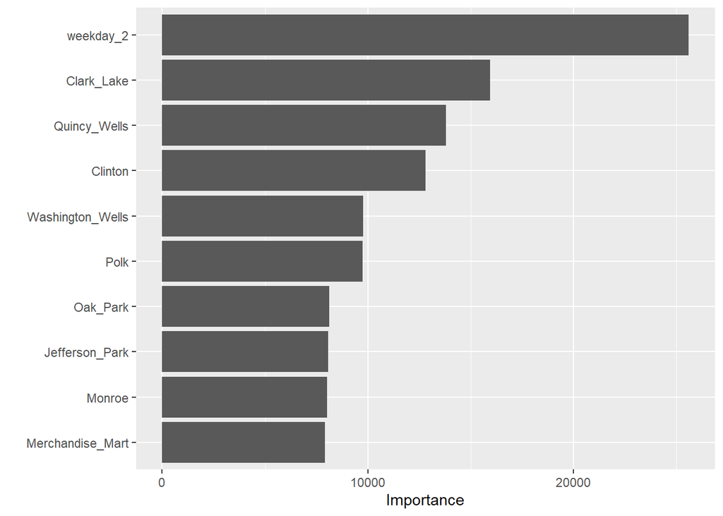

```r
library(vip)
## important predictors
final_fit |>
  extract_fit_parsnip() |>
  vip(num_features = 10)
```

The model is working well, as when we applied it to the test data, we get similar RMSE like we got from the training data, and the model has the lowest RMSE in the training data.

Since this is a random forest model, which is referred to as a black box model, it is neither globally nor locally interpretable.

The most important predictors including weekday and lagging ridership statistics from different stations, especially the lagging stat from the station Clark/Lake itself.